# Results so far

# 1 Market Validation

## 1.1 DTaP Prices

Still to do: visualize infeasible tested instances.

### 1.1.1 Inflation bounds

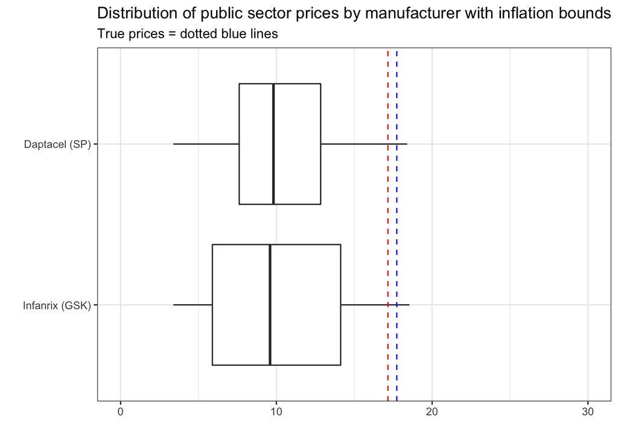

### 1.1.2 No inflation bounds

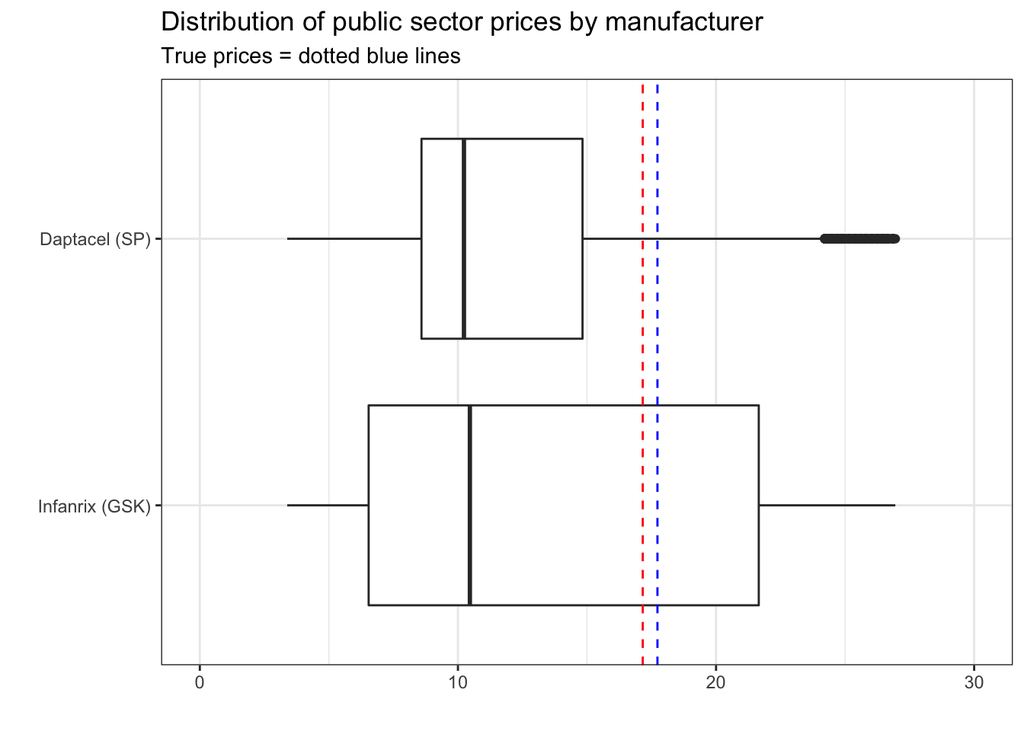

## 1.2 HepB Prices

This tab shows the price distributions of each manufacturer, with and without inflation bounds, for the following tests.

- $\gamma \in [0,0.5]$ because products are dissimilar (e.g., syringe vs. vial), will use $\gamma = 0.25$ as a base for other sensitivity analysis
- $D \in [6.4\times 10^6, 9.24\times 10^6]$, base value $D = 7.032\times 10^6$
- $P_i \in [\$36.9M, \$73.8M]$, base values $P_{rec} = \$58.2$M, $P_{eng} = \$55.1$M.
- $K_i \in [4.031\times10^6,7.032\times10^6]$, base values $K_i = D$ because there was no shortage
- Recombivax HB (Merck) inflation price: $\$12.30\cdot 1.1=\$13.53$
- Engerix B (GSK) inflation price: $\$11.60\cdot 1.1=\$12.76$
- $\mu \in \Theta(10^{-4})$ because CDC cost is $O(p^{\text{pub}}q^{\text{pub}}) = O(10^8)$ and price difference is $O(10^2)$. Empirically, weighting CDC cost more by about two orders of magnitude ensures CDC cost remains the priority while still being able to detect smaller price differences. We use $\mu = 10^{-4}$

Still to do: visualize infeasible tested instances.

### 1.2.1 Inflation bounds

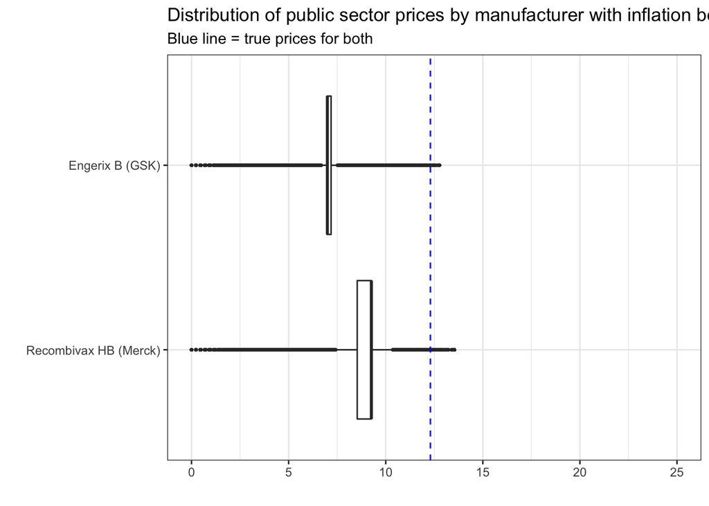

### 1.2.2 No inflation bounds

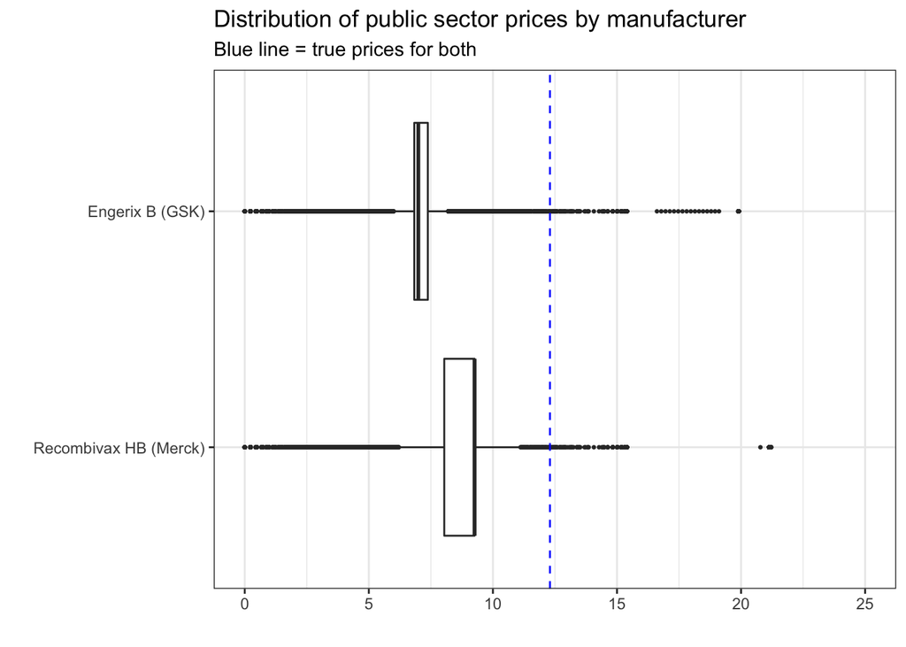

# 2 Feasible regions

Here are the new feasible region visualizations.

## 2.1 DTaP

Base case:

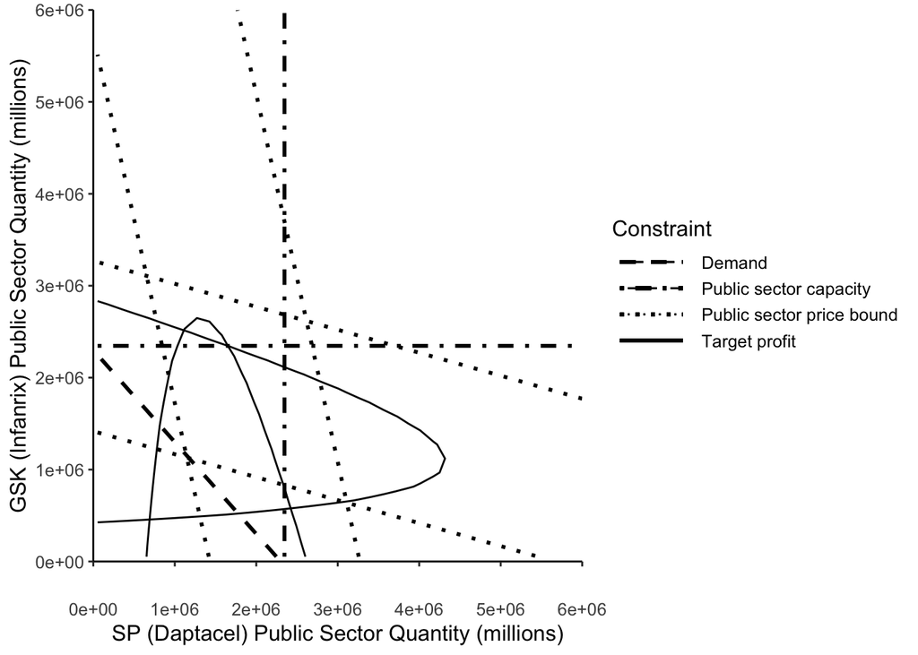

Base case, with equal target profits (same total market target profit), equal inflation bounds (same total)

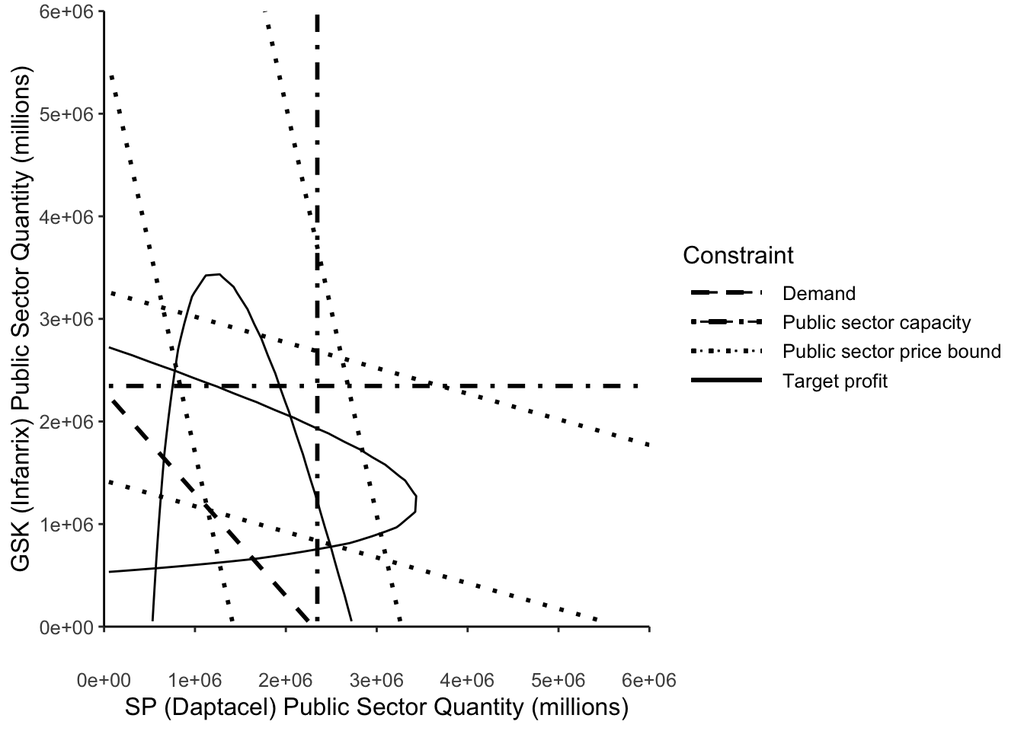

Base case, with equal target profits, higher product similarity ($\gamma = 0.5$), equal inflation bounds

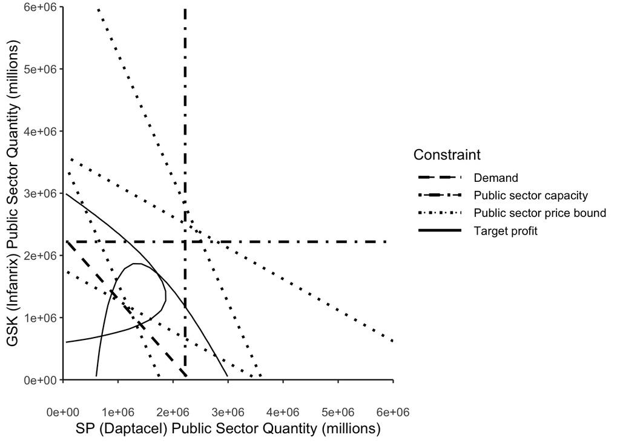

## 2.2 HepB

Base case:

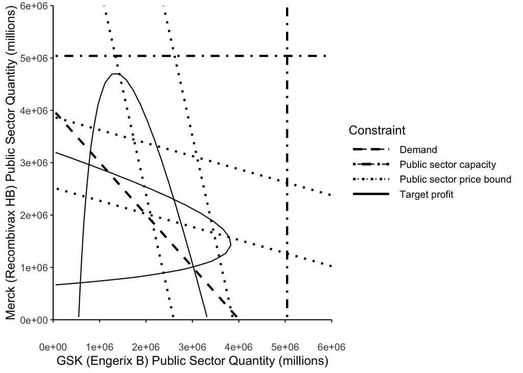

Base case, with equal target profits (same total market target profit)

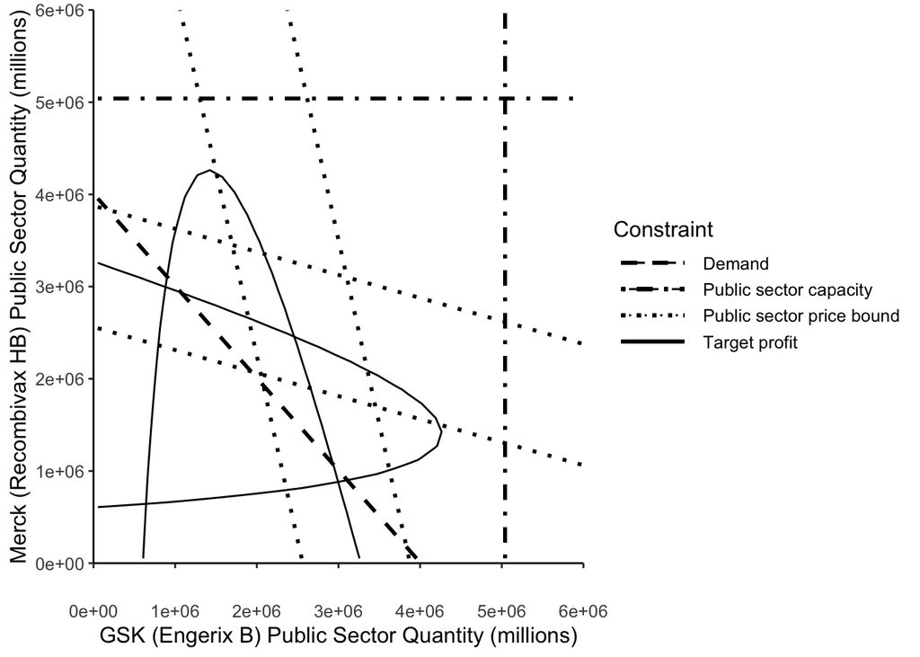

Base case, with equal target profits, and higher product similarity

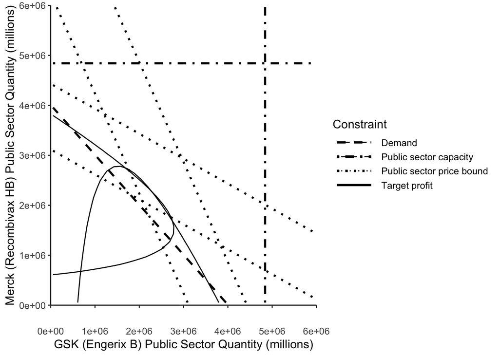

# 3 Heat Maps

## 3.1 Capacities

### 3.1.1 DTaP

Equal target profits, so $(\$43.5M+\$38.5M)/2=\$41M$.

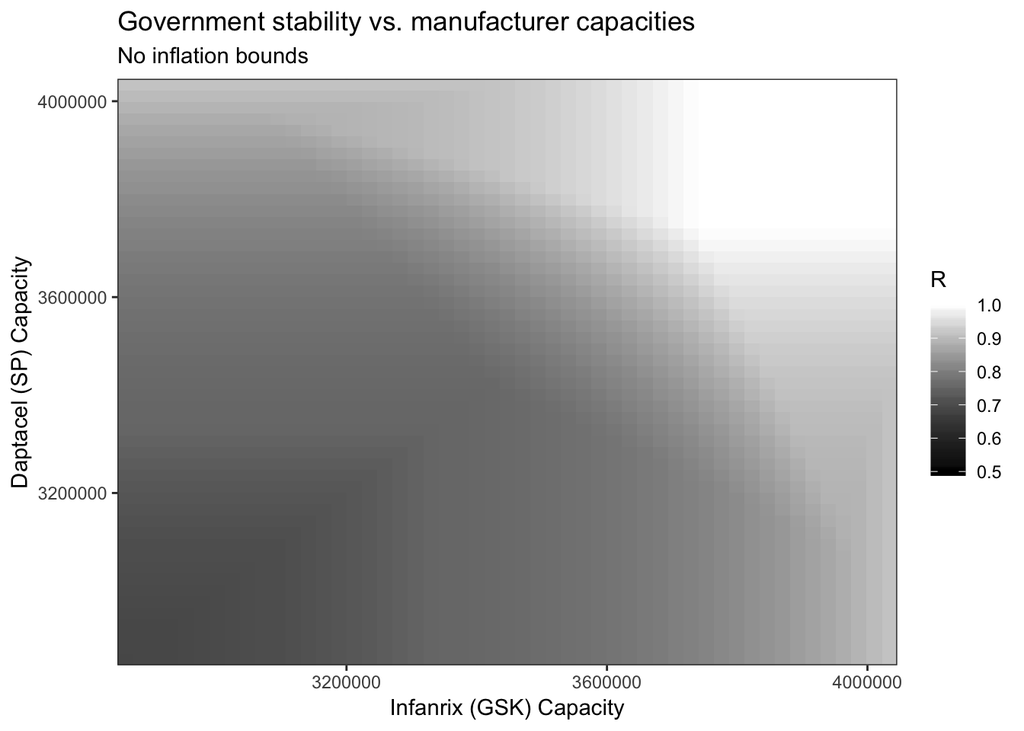

## 3.2 Target Profits

### 3.2.1 DTaP

Equal capacities

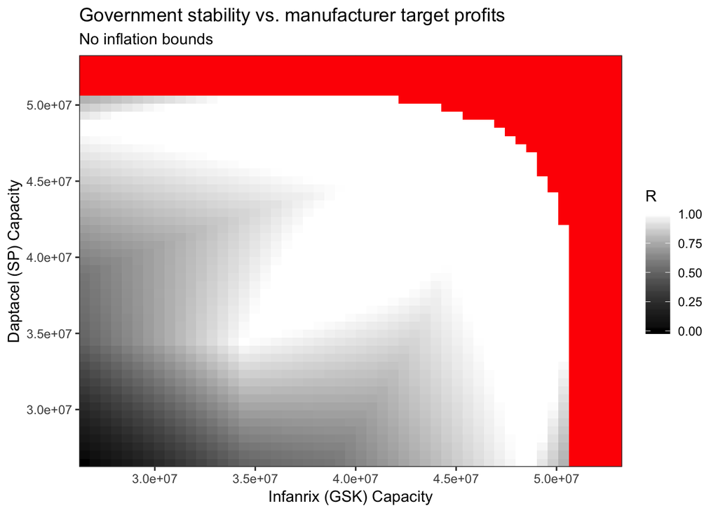

## 3.3 Demand vs. capacity difference

### 3.3.1 DTaP

Equal target profits of $41M.

Minimum capacity needs to be such that each manufacturer can produce enough in the private sector. Since $q_i^{\text{priv}}=1.68M$, we test manufacturer 1 capacity $K \in [1.68M, 4.032M]$, with manufacturer 2’s capacity being in $[4.032M, 8.064M-1.68M] = [4.032M, 6.384M]$. We are keeping the total market capacity the same as in the baseline case, so $2K = 4.032M = 8.064M$. We also equalize target profits to control for the effect of capacity difference.

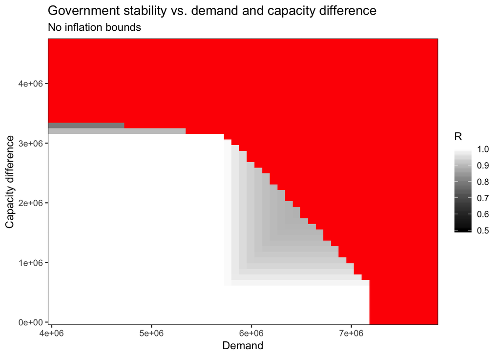

### 3.3.2 HepB

Equal target profits of $56.65M. $K \in [1.98M, 7.032M]$. $K_total = 14.064M$. $K_int = 101040$. $D \in [6.4M, 9.24M], D_{int} = 56800$.

## 3.4 Demand vs. target profit difference

### 3.4.1 DTaP

We keep total market target profit the same, so $82M. Minimum target profit needs to be the amount that manufacturers earn in the private sector, so manufacturer 1 target profit is in the range $P \in [\$26.5M, \$41M]$, which means manufacturer 2 is in the range $[\$41M, \$82M - \$26.5M] = [\$41M, \$55.5M]$.

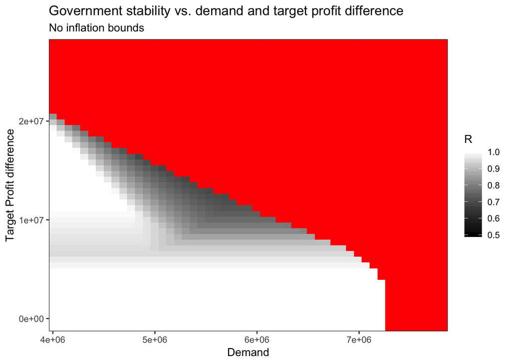

### 3.4.2 HepB

Equal (high) capacities of $7.032M. $P \in [36.9M, 56.65M], P_{int} = 395K, P_{total}=113.3M.$ $D \in [6.4M, 9.24M], D_{int} = 56800$.

## 3.5 Capacity difference vs. target profit difference

### 3.5.1 DTaP

Base $\gamma = 0.25$

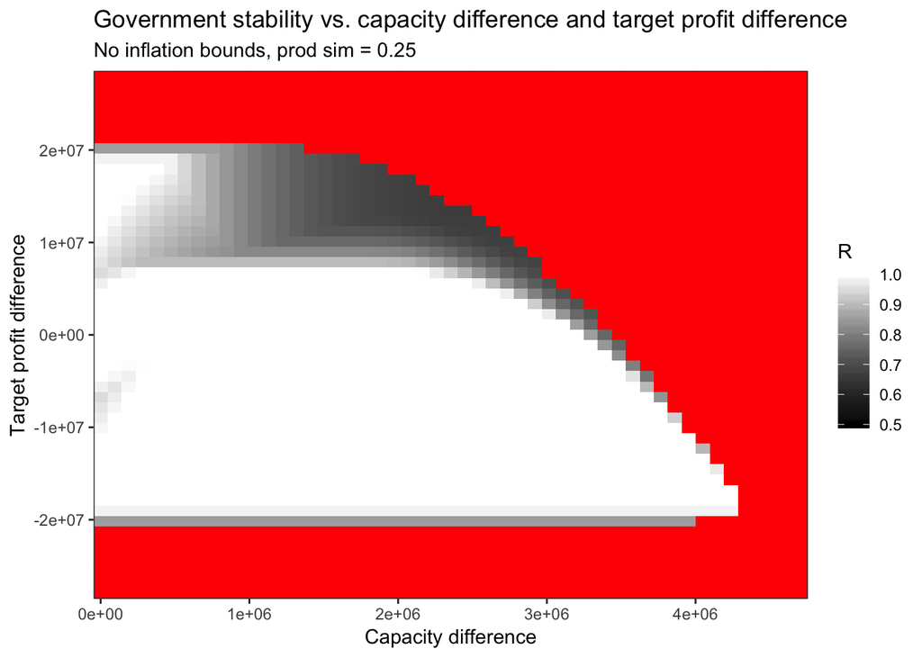

Higher $\gamma = 0.3$

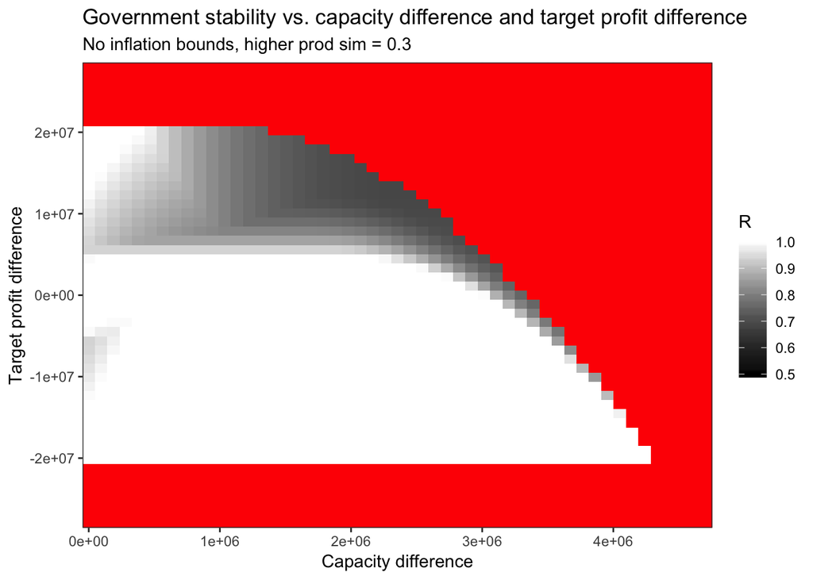

Looks too similar. Need to run for higher $\gamma$.